# Escaped Muons

Adam Lyon

2017-03-21

# 1 Introduction

The goal of this document is to examine “escaped muons” that do not decay in the storage region and do not enter a calorimeter. Some of these muons may leave the storage ring altogether.

I generated art files of simulated events using `mdc2` with different magnetic fields turned on or off (scenarios). We want to examine,

- Muons that are eaten by the iron yoke and muons that escape the world volume entirely.
- Where do muons escape the world (3D and heat map plots?)
- Comparison of the different scenarios

```r
# Load necessary libraries
library(stringr)   # string functions
library(parallel)  # Parallel processing (built-in to R)
library(dplyr)     # data analysis
library(purrr)     # Functional programming
library(readr)     # Read formats
library(ggplot2)   # ploting
library(rgl)       # 3D plots
library(gridExtra) # Arranging plots
library(testthat)  # testing
#
library(readGallery) # Read art Gallery files
```

```r
# Put all readGallery::useDataProduct calls here
useDataProduct('std::vector<gm2truth::TrackingActionArtRecord>')
```

# 2 Load the samples

Samples are located on the Fermilab dCache in the directory `/pnfs/GM2/scratch/users/lyon/arr_20170321`.

```r
# Function to properly alter paths to accomodate XRootD
#    e.g. convert /pnfs/BLA --> root://fndca1.fnal.gov/pnfs/fnal.gov/usr/BLA
xrootd_ify <- function(aPath) paste0('root://fndca1.fnal.gov/pnfs/fnal.gov/usr', str_replace(aPath, '/pnfs', ''))
```

Determine the locations of the data files

```r
# Determine locations of our files
system("ssh lyon@gm2gpvm04.fnal.gov 'ls /pnfs/GM2/scratch/users/lyon/arr_20170321/*/*.root'", intern=T) -> arrFiles
arrFiles %>% xrootd_ify() -> arrXrdFiles
arrXrdFiles
```

```
 [1] "root://fndca1.fnal.gov/pnfs/fnal.gov/usr/GM2/scratch/users/lyon/arr_20170321/15243525_0/ARR_unified_everything_cyl.root"
 [2] "root://fndca1.fnal.gov/pnfs/fnal.gov/usr/GM2/scratch/users/lyon/arr_20170321/15243526_0/ARR_unified_noDipole_cyl.root"
 [3] "root://fndca1.fnal.gov/pnfs/fnal.gov/usr/GM2/scratch/users/lyon/arr_20170321/15243527_0/ARR_unified_noInflector_cyl.root"
 [4] "root://fndca1.fnal.gov/pnfs/fnal.gov/usr/GM2/scratch/users/lyon/arr_20170321/15243528_0/ARR_unified_noKickerQuads_cyl.root"
 [5] "root://fndca1.fnal.gov/pnfs/fnal.gov/usr/GM2/scratch/users/lyon/arr_20170321/15243530_0/ARR_unified_noKicker_cyl.root"
 [6] "root://fndca1.fnal.gov/pnfs/fnal.gov/usr/GM2/scratch/users/lyon/arr_20170321/15243532_0/ARR_unified_noQuads_cyl.root"
 [7] "root://fndca1.fnal.gov/pnfs/fnal.gov/usr/GM2/scratch/users/lyon/arr_20170321/15243540_0/ARR_unified_everything_cyl.root"
 [8] "root://fndca1.fnal.gov/pnfs/fnal.gov/usr/GM2/scratch/users/lyon/arr_20170321/15243542_0/ARR_unified_noDipole_cyl.root"
 [9] "root://fndca1.fnal.gov/pnfs/fnal.gov/usr/GM2/scratch/users/lyon/arr_20170321/15243544_0/ARR_unified_noInflector_cyl.root"
[10] "root://fndca1.fnal.gov/pnfs/fnal.gov/usr/GM2/scratch/users/lyon/arr_20170321/15243547_0/ARR_unified_noKickerQuads_cyl.root"
[11] "root://fndca1.fnal.gov/pnfs/fnal.gov/usr/GM2/scratch/users/lyon/arr_20170321/15243548_0/ARR_unified_noKicker_cyl.root"
[12] "root://fndca1.fnal.gov/pnfs/fnal.gov/usr/GM2/scratch/users/lyon/arr_20170321/15243552_0/ARR_unified_noQuads_cyl.root"
```

Pull out the scenaios (these will be in the same order as the file names)

```r
scenarios <- str_match(arrFiles, 'arr_20170321/.+unified_(.+)_cyl')[,2]
scenarios %>% unique()
```

```
[1] "everything"    "noDipole"      "noInflector"   "noKickerQuads" "noKicker"      "noQuads"
```

Let’s look at the contents of these files (they’re all the same, so we’ll just do one) `gm2 v7_04_00` will have `product_sizes_dumper`.

```r
stringToRun <- str_interp(
  "ssh lyon@gm2gpvm04.fnal.gov 'source /cvmfs/gm2.opensciencegrid.org/prod7/g-2/setup
  setup gm2 v7_04_00 -q prof ;
  product_sizes_dumper ${aFile} | grep ::'",
  list(aFile = arrFiles[1])
)
#
system(stringToRun)
```

```
        1410762186      0.456 gm2truth::MagnetIronAndCryoArtRecords_artg4_magnetIronAndCryostat_mdc2arr.
         660570363      0.214 gm2truth::TrackingActionArtRecords_artg4__mdc2arr.
         637307490      0.206 gm2truth::TrajectoryArtRecords_artg4__mdc2arr.
         240738334      0.078 gm2ringsim::GeantTrackRecords_artg4_KeepStepsAction_mdc2arr.
         118035827      0.038 gm2truth::RingArtRecords_artg4_Ring_mdc2arr.
          12078805      0.004 gm2truth::GhostDetectorArtRecords_artg4_GhostCylinderDetector_mdc2arr.
           4482185      0.001 art::RNGsnapshots_randomsaver__mdc2arr.
           4086898      0.001 gm2truth::RingTrackingPlaneArtRecords_artg4_RingTrackingPlanes_mdc2arr.
           1373178      0.000 gm2truth::GhostDetectorArtRecords_artg4_GhostNearWorldDetector_mdc2arr.
           1185772      0.000 gm2truth::PhaseSpaceArtRecord_artg4__mdc2arr.
             36971      0.000 art::TriggerResults_TriggerResults__mdc2arr.
```

# 3 Escaping muons from the Tracking Action data

The tracking action data has birth and death data for every Geant track.

## 3.1 Load Tracking Action data

We’ll capture this information for the primary muon and its first generation daughters. See [gm2dataproducts/mc/actions/track/TrackingActionArtRecord.hh](https://redmine.fnal.gov/redmine/projects/gm2dataproducts/repository/entry/mc/actions/track/TrackingActionArtRecord.hh?rev=feature%2Fmdc2).

We need a `readGallery` reader python class. Generate with,

```r
readerClassSkel('gm2truth::TrackingActionArtRecord', writeFile = 'trackingActionReader.py')
```

Here is the reader,

```r
read_file('trackingActionReader.py') %>% cat
```

```
from readGallery import GalleryReaderBase  # Necessary for the base class

class TrackingActionArtRecordReader(GalleryReaderBase):
  def __init__(self, inputTag):
    GalleryReaderBase.__init__(self, inputTag)
    self.names = ['fileEntry', 'eventEntry', 'trackType', 'trackID',
                  'parentTrackID', 'turn', 'volumeUID', 'status',  'p', 'e', 'x', 'y', 'z', 'px', 'py', 'pz']

  def prepare(self, ROOT, ev):
    GalleryReaderBase.prepare(self, ROOT, ev)
    self.getValidHandle = ev.getValidHandle(ROOT.vector(ROOT.gm2truth.TrackingActionArtRecord))

  def fill(self, ROOT, ev):

    validHandle = self.getValidHandle(self.inputTag)  # Get the valid handle for
                                                      # gm2truth::TrackingActionArtRecord

    if not validHandle.empty():                       # Does it have data?

      p = validHandle.product()                       # Get the corresponding data product (maybe a vector)

      # Fill from gm2truth::TrackingActionArtRecord
      for e in p:                             # Loop over elements and fill

        # Only accept the primary muon death and its first generation daughters birth
        if (e.trackID == 1 and e.status == 1) or (e.parentTrackID == 1 and e.status == 0):

          self.vals.append(
            [ ev.fileEntry(), ev.eventEntry(), e.trackType, e.trackID,
              e.parentTrackID, e.turn, e.volumeUID, e.status, e.p, e.e,
              e.x, e.y, e.z, e.px, e.py, e.pz ])

    return True
```

Make the reader class and object

```r
trackingActionReaderC <- createReaderClass_from_file('trackingActionReader.py')$TrackingActionArtRecordReader
```

We have many files to process. Let’s do this reading in `parallel`.

We need to create a reader object per parallel job

```r
trackingActionReaders <- map(1:length(arrXrdFiles), function(i) trackingActionReaderC(artInputTag("artg4")))
```

Load the data

```r
jobs <- lapply(1:length(arrXrdFiles), function(i) getGalleryData(arrXrdFiles[i], trackingActionReaders[[i]]) %>%
                                                    mcparallel(name=i))
```

```
Opening first file...
Successfully opened file root://fndca1.fnal.gov/pnfs/fnal.gov/usr/GM2/scratch/users/lyon/arr_20170321/15243525_0/ARR_unified_everything_cyl.root
Closing file, read 663158402 bytes in 161 transactions
Timings: Overall time = 200.338 s
Time per event: min=0.000   mean=0.019   max=7.364
Opening first file...
Successfully opened file root://fndca1.fnal.gov/pnfs/fnal.gov/usr/GM2/scratch/users/lyon/arr_20170321/15243526_0/ARR_unified_noDipole_cyl.root
Closing file, read 657073380 bytes in 158 transactions
Timings: Overall time = 228.757 s
Time per event: min=0.000   mean=0.022   max=27.028
Opening first file...
Successfully opened file root://fndca1.fnal.gov/pnfs/fnal.gov/usr/GM2/scratch/users/lyon/arr_20170321/15243527_0/ARR_unified_noInflector_cyl.root
Closing file, read 668231087 bytes in 160 transactions
Timings: Overall time = 208.320 s
Time per event: min=0.000   mean=0.020   max=16.990
Opening first file...
Successfully opened file root://fndca1.fnal.gov/pnfs/fnal.gov/usr/GM2/scratch/users/lyon/arr_20170321/15243528_0/ARR_unified_noKickerQuads_cyl.root
Closing file, read 664723747 bytes in 161 transactions
Timings: Overall time = 200.955 s
Time per event: min=0.000   mean=0.019   max=8.426
Opening first file...
Successfully opened file root://fndca1.fnal.gov/pnfs/fnal.gov/usr/GM2/scratch/users/lyon/arr_20170321/15243530_0/ARR_unified_noKicker_cyl.root
Closing file, read 666316280 bytes in 160 transactions
Timings: Overall time = 234.668 s
Time per event: min=0.000   mean=0.022   max=17.103
Opening first file...
Successfully opened file root://fndca1.fnal.gov/pnfs/fnal.gov/usr/GM2/scratch/users/lyon/arr_20170321/15243532_0/ARR_unified_noQuads_cyl.root
Closing file, read 664218464 bytes in 136 transactions
Timings: Overall time = 535.363 s
Time per event: min=0.000   mean=0.053   max=334.559
Opening first file...
Successfully opened file root://fndca1.fnal.gov/pnfs/fnal.gov/usr/GM2/scratch/users/lyon/arr_20170321/15243540_0/ARR_unified_everything_cyl.root
Closing file, read 660527554 bytes in 161 transactions
Timings: Overall time = 266.787 s
Time per event: min=0.000   mean=0.026   max=21.746
Opening first file...
Successfully opened file root://fndca1.fnal.gov/pnfs/fnal.gov/usr/GM2/scratch/users/lyon/arr_20170321/15243542_0/ARR_unified_noDipole_cyl.root
Closing file, read 656304716 bytes in 158 transactions
Timings: Overall time = 209.096 s
Time per event: min=0.000   mean=0.021   max=17.045
Opening first file...
Successfully opened file root://fndca1.fnal.gov/pnfs/fnal.gov/usr/GM2/scratch/users/lyon/arr_20170321/15243544_0/ARR_unified_noInflector_cyl.root
Closing file, read 668176375 bytes in 160 transactions
Timings: Overall time = 209.131 s
Time per event: min=0.000   mean=0.020   max=11.414
Opening first file...
Successfully opened file root://fndca1.fnal.gov/pnfs/fnal.gov/usr/GM2/scratch/users/lyon/arr_20170321/15243547_0/ARR_unified_noKickerQuads_cyl.root
Closing file, read 664807569 bytes in 161 transactions
Timings: Overall time = 216.531 s
Time per event: min=0.000   mean=0.021   max=17.764
Opening first file...
Successfully opened file root://fndca1.fnal.gov/pnfs/fnal.gov/usr/GM2/scratch/users/lyon/arr_20170321/15243548_0/ARR_unified_noKicker_cyl.root
Closing file, read 666316217 bytes in 160 transactions
Timings: Overall time = 227.132 s
Time per event: min=0.000   mean=0.022   max=13.152
Opening first file...
Successfully opened file root://fndca1.fnal.gov/pnfs/fnal.gov/usr/GM2/scratch/users/lyon/arr_20170321/15243552_0/ARR_unified_noQuads_cyl.root
Closing file, read 665617262 bytes in 161 transactions
Timings: Overall time = 221.986 s
Time per event: min=0.000   mean=0.021   max=9.361
```

```r
trackingActionReturns <- mccollect(jobs)
```

Let’s merge all of the output.

```r
trackingActionDF <- map_df(1:length(trackingActionReaders),
                           function(i) galleryReader_df(trackingActionReaders[[i]]) %>% mutate(scenario=scenarios[i],
                                                                                               fileEntry=i))
trackingActionDF
```

| fileEntry | eventEntry | trackType | trackID | parentTrackID | turn | volumeUID | status | p | e | x | y | z | px | py | pz | scenario |
| --- | --- | --- | --- | --- | --- | --- | --- | --- | --- | --- | --- | --- | --- | --- | --- | --- |
| 1 | 0 | mu+ | 1 | 0 | 0 | 16 | 1 | 0.000000e+00 | 1.056584e+02 | -1028.77033 | 96.5396253 | 7507.0843 | 0.000000e+00 | 0.000000e+00 | 0.000000e+00 | everything |
| 1 | 0 | e+ | 173 | 1 | 0 | 16 | 0 | 4.481449e+01 | 4.481741e+01 | -1028.77033 | 96.5396253 | 7507.0843 | -5.797972e+00 | -1.716866e+01 | -4.098731e+01 | everything |
| 1 | 0 | nu_e | 172 | 1 | 0 | 16 | 0 | 3.562549e+01 | 3.562549e+01 | -1028.77033 | 96.5396253 | 7507.0843 | -1.313140e+01 | 2.175334e+01 | 2.497067e+01 | everything |
| 1 | 0 | anti_nu_mu | 171 | 1 | 0 | 16 | 0 | 2.521652e+01 | 2.521652e+01 | -1028.77033 | 96.5396253 | 7507.0843 | 1.892937e+01 | -4.584678e+00 | 1.601664e+01 | everything |
| 1 | 0 | Fe56 | 142 | 1 | 0 | 15 | 0 | 1.493304e+02 | 5.209002e+04 | -441.59752 | 95.9049995 | 7252.9760 | -2.800483e+01 | -1.284009e+02 | -7.091207e+01 | everything |
| 1 | 1 | mu+ | 1 | 0 | 0 | 22 | 1 | 0.000000e+00 | 1.056584e+02 | 5013.58011 | 301.2490823 | 5492.2865 | 0.000000e+00 | 0.000000e+00 | 0.000000e+00 | everything |
| 1 | 1 | e+ | 158 | 1 | 0 | 22 | 0 | 2.610116e+01 | 2.610616e+01 | 5013.58011 | 301.2490823 | 5492.2865 | -1.036858e+01 | -1.247094e+01 | -2.045088e+01 | everything |
| 1 | 1 | nu_e | 157 | 1 | 0 | 22 | 0 | 3.823168e+01 | 3.823168e+01 | 5013.58011 | 301.2490823 | 5492.2865 | 1.268521e+01 | -2.876454e+01 | 2.175657e+01 | everything |
| 1 | 1 | anti_nu_mu | 156 | 1 | 0 | 22 | 0 | 4.132114e+01 | 4.132114e+01 | 5013.58011 | 301.2490823 | 5492.2865 | -2.316624e+00 | 4.123548e+01 | -1.305684e+00 | everything |
| 1 | 2 | mu+ | 1 | 0 | 0 | 16 | 1 | 0.000000e+00 | 1.056584e+02 | 4250.40660 | 20.6381799 | 6266.8227 | 0.000000e+00 | 0.000000e+00 | 0.000000e+00 | everything |

[output cut: 990 more lines]

```r
write_rds(trackingActionDF, 'trackingActionDF.rds')
```

How many muons per file?

```r
trackingActionDF %>% filter(trackID==1) %>% group_by(scenario, fileEntry) %>% tally()
```

| scenario | fileEntry | n |
| --- | --- | --- |
| everything | 1 | 10000 |
| everything | 7 | 10000 |
| noDipole | 2 | 10000 |
| noDipole | 8 | 10000 |
| noInflector | 3 | 10000 |
| noInflector | 9 | 10000 |
| noKicker | 5 | 10000 |
| noKicker | 11 | 10000 |
| noKickerQuads | 4 | 10000 |
| noKickerQuads | 10 | 10000 |

[output cut: 2 more lines]

### 3.1.1 Add Volume Names

We need to turn the volume IDs into volume names. The volume IDs change for each file. We can run a small art job to determine the volume ID to name tables.

```r
runForVolIDString <- function(i) {
  str_interp(
    "PVS_CSVOUT=${csvout}_${i}_volNames.csv gm2 -c ${fclPath}/gm2analyses/fcl/physicalVolumeStoreToFile.fcl -n 1 ${aFile}",
    list( csvout=scenarios[i], i=i, fclPath=Sys.getenv("MRB_BUILDDIR"), aFile=arrXrdFiles[i])
  )
}
runForVolIDStrings <- sapply(1:length(arrXrdFiles), runForVolIDString)
runForVolIDStrings
```

```
 [1] "PVS_CSVOUT=everything_1_volNames.csv gm2 -c /home/me/gm2/renee_arr/build_slf7.x86_64/gm2analyses/fcl/physicalVolumeStoreToFile.fcl -n 1 root://fndca1.fnal.gov/pnfs/fnal.gov/usr/GM2/scratch/users/lyon/arr_20170321/15243525_0/ARR_unified_everything_cyl.root"
 [2] "PVS_CSVOUT=noDipole_2_volNames.csv gm2 -c /home/me/gm2/renee_arr/build_slf7.x86_64/gm2analyses/fcl/physicalVolumeStoreToFile.fcl -n 1 root://fndca1.fnal.gov/pnfs/fnal.gov/usr/GM2/scratch/users/lyon/arr_20170321/15243526_0/ARR_unified_noDipole_cyl.root"
 [3] "PVS_CSVOUT=noInflector_3_volNames.csv gm2 -c /home/me/gm2/renee_arr/build_slf7.x86_64/gm2analyses/fcl/physicalVolumeStoreToFile.fcl -n 1 root://fndca1.fnal.gov/pnfs/fnal.gov/usr/GM2/scratch/users/lyon/arr_20170321/15243527_0/ARR_unified_noInflector_cyl.root"
 [4] "PVS_CSVOUT=noKickerQuads_4_volNames.csv gm2 -c /home/me/gm2/renee_arr/build_slf7.x86_64/gm2analyses/fcl/physicalVolumeStoreToFile.fcl -n 1 root://fndca1.fnal.gov/pnfs/fnal.gov/usr/GM2/scratch/users/lyon/arr_20170321/15243528_0/ARR_unified_noKickerQuads_cyl.root"
 [5] "PVS_CSVOUT=noKicker_5_volNames.csv gm2 -c /home/me/gm2/renee_arr/build_slf7.x86_64/gm2analyses/fcl/physicalVolumeStoreToFile.fcl -n 1 root://fndca1.fnal.gov/pnfs/fnal.gov/usr/GM2/scratch/users/lyon/arr_20170321/15243530_0/ARR_unified_noKicker_cyl.root"
 [6] "PVS_CSVOUT=noQuads_6_volNames.csv gm2 -c /home/me/gm2/renee_arr/build_slf7.x86_64/gm2analyses/fcl/physicalVolumeStoreToFile.fcl -n 1 root://fndca1.fnal.gov/pnfs/fnal.gov/usr/GM2/scratch/users/lyon/arr_20170321/15243532_0/ARR_unified_noQuads_cyl.root"
 [7] "PVS_CSVOUT=everything_7_volNames.csv gm2 -c /home/me/gm2/renee_arr/build_slf7.x86_64/gm2analyses/fcl/physicalVolumeStoreToFile.fcl -n 1 root://fndca1.fnal.gov/pnfs/fnal.gov/usr/GM2/scratch/users/lyon/arr_20170321/15243540_0/ARR_unified_everything_cyl.root"
 [8] "PVS_CSVOUT=noDipole_8_volNames.csv gm2 -c /home/me/gm2/renee_arr/build_slf7.x86_64/gm2analyses/fcl/physicalVolumeStoreToFile.fcl -n 1 root://fndca1.fnal.gov/pnfs/fnal.gov/usr/GM2/scratch/users/lyon/arr_20170321/15243542_0/ARR_unified_noDipole_cyl.root"
 [9] "PVS_CSVOUT=noInflector_9_volNames.csv gm2 -c /home/me/gm2/renee_arr/build_slf7.x86_64/gm2analyses/fcl/physicalVolumeStoreToFile.fcl -n 1 root://fndca1.fnal.gov/pnfs/fnal.gov/usr/GM2/scratch/users/lyon/arr_20170321/15243544_0/ARR_unified_noInflector_cyl.root"
[10] "PVS_CSVOUT=noKickerQuads_10_volNames.csv gm2 -c /home/me/gm2/renee_arr/build_slf7.x86_64/gm2analyses/fcl/physicalVolumeStoreToFile.fcl -n 1 root://fndca1.fnal.gov/pnfs/fnal.gov/usr/GM2/scratch/users/lyon/arr_20170321/15243547_0/ARR_unified_noKickerQuads_cyl.root"
[11] "PVS_CSVOUT=noKicker_11_volNames.csv gm2 -c /home/me/gm2/renee_arr/build_slf7.x86_64/gm2analyses/fcl/physicalVolumeStoreToFile.fcl -n 1 root://fndca1.fnal.gov/pnfs/fnal.gov/usr/GM2/scratch/users/lyon/arr_20170321/15243548_0/ARR_unified_noKicker_cyl.root"
[12] "PVS_CSVOUT=noQuads_12_volNames.csv gm2 -c /home/me/gm2/renee_arr/build_slf7.x86_64/gm2analyses/fcl/physicalVolumeStoreToFile.fcl -n 1 root://fndca1.fnal.gov/pnfs/fnal.gov/usr/GM2/scratch/users/lyon/arr_20170321/15243552_0/ARR_unified_noQuads_cyl.root"
```

Let’s run the art jobs in parallel

```r
jobs <- lapply(1:length(arrXrdFiles), function(i) mcparallel(system( runForVolIDStrings[i], intern=T ), name=i))
res <- mccollect(jobs)
```

and load the CSV files.

```r
jobs <- lapply(1:length(arrFiles), function(i)
  str_interp("${scn}_${i}_volNames.csv", list(scn=scenarios[i], i=i)) %>%
    read_csv(col_names=c("volumeUID", "volName")) %>% mcparallel(name=i) )
#
volNameTables <- mccollect(jobs)
volNameDF <- map_df(1:length(volNameTables), function(i)
                      volNameTables[[i]] %>% mutate(scenario=scenarios[i],
                                                    fileEntry=i))
volNameDF
```

| volumeUID | volName | scenario | fileEntry |
| --- | --- | --- | --- |
| 0 | ArcSection[00] | everything | 1 |
| 1 | VacuumChamberCadMeshWallPV[11] | everything | 1 |
| 2 | InflectorBoundingBox | everything | 1 |
| 3 | InflectorCryoWindowUS | everything | 1 |
| 4 | InflectorCoilUS | everything | 1 |
| 5 | InflectorMandrelWindowUS | everything | 1 |
| 6 | InflectorAperture | everything | 1 |
| 7 | InflectorMandrelWindowDS | everything | 1 |
| 8 | InflectorCoilDS | everything | 1 |
| 9 | InflectorCryoWindowDS | everything | 1 |

[output cut: 990 more lines]

Now we merge with the tracking action data frame

```r
trackingActionDF %>% inner_join(volNameDF) %>%
  select(scenario, fileEntry, eventEntry, volName, everything()) -> trackingActionNDF
trackingActionNDF
```

| scenario | fileEntry | eventEntry | volName | trackType | trackID | parentTrackID | turn | volumeUID | status | p | e | x | y | z | px | py | pz |
| --- | --- | --- | --- | --- | --- | --- | --- | --- | --- | --- | --- | --- | --- | --- | --- | --- | --- |
| everything | 1 | 0 | RingCryoOuter | mu+ | 1 | 0 | 0 | 16 | 1 | 0.000000e+00 | 1.056584e+02 | -1028.77033 | 96.5396253 | 7507.0843 | 0.000000e+00 | 0.000000e+00 | 0.000000e+00 |
| everything | 1 | 0 | RingCryoOuter | e+ | 173 | 1 | 0 | 16 | 0 | 4.481449e+01 | 4.481741e+01 | -1028.77033 | 96.5396253 | 7507.0843 | -5.797972e+00 | -1.716866e+01 | -4.098731e+01 |
| everything | 1 | 0 | RingCryoOuter | nu_e | 172 | 1 | 0 | 16 | 0 | 3.562549e+01 | 3.562549e+01 | -1028.77033 | 96.5396253 | 7507.0843 | -1.313140e+01 | 2.175334e+01 | 2.497067e+01 |
| everything | 1 | 0 | RingCryoOuter | anti_nu_mu | 171 | 1 | 0 | 16 | 0 | 2.521652e+01 | 2.521652e+01 | -1028.77033 | 96.5396253 | 7507.0843 | 1.892937e+01 | -4.584678e+00 | 1.601664e+01 |
| everything | 1 | 0 | RingPoleTipUpper | Fe56 | 142 | 1 | 0 | 15 | 0 | 1.493304e+02 | 5.209002e+04 | -441.59752 | 95.9049995 | 7252.9760 | -2.800483e+01 | -1.284009e+02 | -7.091207e+01 |
| everything | 1 | 1 | RingYokeTop | mu+ | 1 | 0 | 0 | 22 | 1 | 0.000000e+00 | 1.056584e+02 | 5013.58011 | 301.2490823 | 5492.2865 | 0.000000e+00 | 0.000000e+00 | 0.000000e+00 |
| everything | 1 | 1 | RingYokeTop | e+ | 158 | 1 | 0 | 22 | 0 | 2.610116e+01 | 2.610616e+01 | 5013.58011 | 301.2490823 | 5492.2865 | -1.036858e+01 | -1.247094e+01 | -2.045088e+01 |
| everything | 1 | 1 | RingYokeTop | nu_e | 157 | 1 | 0 | 22 | 0 | 3.823168e+01 | 3.823168e+01 | 5013.58011 | 301.2490823 | 5492.2865 | 1.268521e+01 | -2.876454e+01 | 2.175657e+01 |
| everything | 1 | 1 | RingYokeTop | anti_nu_mu | 156 | 1 | 0 | 22 | 0 | 4.132114e+01 | 4.132114e+01 | 5013.58011 | 301.2490823 | 5492.2865 | -2.316624e+00 | 4.123548e+01 | -1.305684e+00 |
| everything | 1 | 2 | RingCryoOuter | mu+ | 1 | 0 | 0 | 16 | 1 | 0.000000e+00 | 1.056584e+02 | 4250.40660 | 20.6381799 | 6266.8227 | 0.000000e+00 | 0.000000e+00 | 0.000000e+00 |

[output cut: 990 more lines]

## 3.2 How many muons decay in the storage region?

These muon decay in the storage region (not quite the same as “stored”),

```r
trackingActionNDF %>% filter(trackID==1, volName=='ArcSection[00]') %>%
  group_by(scenario, fileEntry) %>% tally()
```

| scenario | fileEntry | n |
| --- | --- | --- |
| everything | 1 | 65 |
| everything | 7 | 50 |
| noDipole | 2 | 2 |
| noDipole | 8 | 3 |
| noInflector | 3 | 6 |
| noInflector | 9 | 6 |
| noKicker | 5 | 14 |
| noKicker | 11 | 14 |
| noKickerQuads | 4 | 14 |
| noKickerQuads | 10 | 5 |

[output cut: 2 more lines]

Interesting! So, from this, only 0.575% decay in the storage region for the “all on” (or everything) sample. That seems rather low. But continuing.

```r
write_rds(trackingActionNDF, 'trackingActionNDF.rds')
```

## 3.3 Where do muons go to die?

```r
trackingActionNDF %>% filter(trackID == 1) %>% group_by(scenario, volName) %>% tally()
```

| scenario | volName | n |
| --- | --- | --- |
| everything | ArcSection[00] | 115 |
| everything | bellowsRailPV[06] | 1 |
| everything | bellowsRailPV[08] | 1 |
| everything | InflectorAperture | 3 |
| everything | InflectorMandrel | 1 |
| everything | quadPlatePV[01] | 2 |
| everything | quadPlatePV[07] | 1 |
| everything | RingCryoOuter | 1805 |
| everything | RingInnerCryostatLower | 265 |
| everything | RingInnerCryostatUpper | 167 |

[output cut: 131 more lines]

It may be nice to categorize the volume names by area (e.g. “Arc”, “bellows”, “Ring”, “Inflector”).

```r
# Pull out the first word in camel case (see http://stackoverflow.com/questions/29916065/how-to-do-camelcase-split-in-python)
camelCaseSplit <- function(s) str_split(s, '(?<=[a-z])(?=[A-Z])|(?<=[A-Z])(?=[A-Z][a-z])')
```

```r
# Test the above
expect_equal(camelCaseSplit("RingPoleTipUpper")[[1]], c("Ring", "Pole", "Tip", "Upper"))
expect_equal(camelCaseSplit("ringPoleTipUpper")[[1]], c("ring", "Pole", "Tip", "Upper"))
expect_equal(camelCaseSplit("world")[[1]], c("world"))
expect_equal(camelCaseSplit("ringPole")[[1]], c("ring", "Pole"))
```

```r
takeFirstCamel <- function(s) camelCaseSplit(s) %>% map_chr(function(s) s[1])
takeFirstCamel("RingPoleTipUpper") %>% expect_equal("Ring")
takeFirstCamel("ringPoleTipUpper") %>% expect_equal("ring")
takeFirstCamel("world") %>% expect_equal("world")
takeFirstCamel("ringPole") %>% expect_equal("ring")
takeFirstCamel(c("ringPoleTipUpper", "world")) %>% expect_equal(c("ring", "world"))
```

```r
trackingActionNDF %>% mutate(volCategory = volName %>% takeFirstCamel) -> trackingActionNVDF
trackingActionNVDF
```

| scenario | fileEntry | eventEntry | volName | trackType | trackID | parentTrackID | turn | volumeUID | status | p | e | x | y | z | px | py | pz | volCategory |
| --- | --- | --- | --- | --- | --- | --- | --- | --- | --- | --- | --- | --- | --- | --- | --- | --- | --- | --- |
| everything | 1 | 0 | RingCryoOuter | mu+ | 1 | 0 | 0 | 16 | 1 | 0.000000e+00 | 1.056584e+02 | -1028.77033 | 96.5396253 | 7507.0843 | 0.000000e+00 | 0.000000e+00 | 0.000000e+00 | Ring |
| everything | 1 | 0 | RingCryoOuter | e+ | 173 | 1 | 0 | 16 | 0 | 4.481449e+01 | 4.481741e+01 | -1028.77033 | 96.5396253 | 7507.0843 | -5.797972e+00 | -1.716866e+01 | -4.098731e+01 | Ring |
| everything | 1 | 0 | RingCryoOuter | nu_e | 172 | 1 | 0 | 16 | 0 | 3.562549e+01 | 3.562549e+01 | -1028.77033 | 96.5396253 | 7507.0843 | -1.313140e+01 | 2.175334e+01 | 2.497067e+01 | Ring |
| everything | 1 | 0 | RingCryoOuter | anti_nu_mu | 171 | 1 | 0 | 16 | 0 | 2.521652e+01 | 2.521652e+01 | -1028.77033 | 96.5396253 | 7507.0843 | 1.892937e+01 | -4.584678e+00 | 1.601664e+01 | Ring |
| everything | 1 | 0 | RingPoleTipUpper | Fe56 | 142 | 1 | 0 | 15 | 0 | 1.493304e+02 | 5.209002e+04 | -441.59752 | 95.9049995 | 7252.9760 | -2.800483e+01 | -1.284009e+02 | -7.091207e+01 | Ring |
| everything | 1 | 1 | RingYokeTop | mu+ | 1 | 0 | 0 | 22 | 1 | 0.000000e+00 | 1.056584e+02 | 5013.58011 | 301.2490823 | 5492.2865 | 0.000000e+00 | 0.000000e+00 | 0.000000e+00 | Ring |
| everything | 1 | 1 | RingYokeTop | e+ | 158 | 1 | 0 | 22 | 0 | 2.610116e+01 | 2.610616e+01 | 5013.58011 | 301.2490823 | 5492.2865 | -1.036858e+01 | -1.247094e+01 | -2.045088e+01 | Ring |
| everything | 1 | 1 | RingYokeTop | nu_e | 157 | 1 | 0 | 22 | 0 | 3.823168e+01 | 3.823168e+01 | 5013.58011 | 301.2490823 | 5492.2865 | 1.268521e+01 | -2.876454e+01 | 2.175657e+01 | Ring |
| everything | 1 | 1 | RingYokeTop | anti_nu_mu | 156 | 1 | 0 | 22 | 0 | 4.132114e+01 | 4.132114e+01 | 5013.58011 | 301.2490823 | 5492.2865 | -2.316624e+00 | 4.123548e+01 | -1.305684e+00 | Ring |
| everything | 1 | 2 | RingCryoOuter | mu+ | 1 | 0 | 0 | 16 | 1 | 0.000000e+00 | 1.056584e+02 | 4250.40660 | 20.6381799 | 6266.8227 | 0.000000e+00 | 0.000000e+00 | 0.000000e+00 | Ring |

[output cut: 990 more lines]

Show count by category

```r
trackingActionNVDF %>% filter(trackID ==1) %>% group_by(scenario, volCategory) %>% tally() -> volCatTally
volCatTally %>% mutate(perc = n/20000 * 100) -> volCatTally
volCatTally
```

| scenario | volCategory | n | perc |
| --- | --- | --- | --- |
| everything | Arc | 115 | 0.575 |
| everything | bellows | 2 | 0.010 |
| everything | Inflector | 4 | 0.020 |
| everything | quad | 3 | 0.015 |
| everything | Ring | 19299 | 96.495 |
| everything | trolley | 6 | 0.030 |
| everything | Vacuum | 31 | 0.155 |
| everything | world | 540 | 2.700 |
| noDipole | Arc | 5 | 0.025 |
| noDipole | Ring | 12771 | 63.855 |

[output cut: 32 more lines]

Let’s plot!

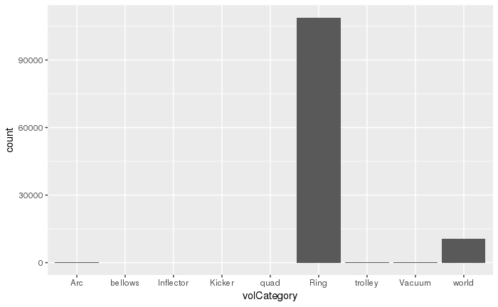

```r
trackingActionNVDF %>% filter(trackID ==1) %>% ggplot(aes(x=volCategory, group=scenario)) +
  geom_bar()
```

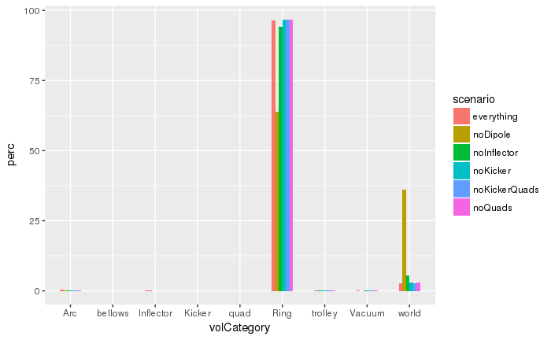

```r
ggplot(volCatTally, aes(x = volCategory, y=perc, fill=scenario)) +
  geom_bar(stat="Identity", width=0.5, position="dodge")
```

Can’t really see non-Ring/world ones. Let’s split them out.

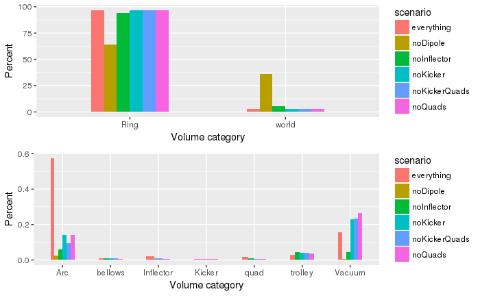

```r
# Function to make this easy
plotit <- function(d) ggplot(d, aes(x = volCategory, y=perc, fill=scenario) ) +
  geom_bar(stat="Identity", width=0.5, position="dodge") +
  xlab("Volume category") + ylab("Percent")
volCatTally %>% filter(volCategory %in% c("Ring", "world")) %>% plotit -> p1
volCatTally %>% filter(! volCategory %in% c("Ring", "world")) %>% plotit -> p2
grid.arrange(p1, p2)
```

Let’s see where they die

```r
plotCommon <- function(p) p +
               facet_wrap(~scenario) +
               guides(col = guide_legend(override.aes = list(size=5, alpha=1))) +
               scale_color_discrete(name="Volume\nCategory") +
               labs(x="z (mm)", y="x (mm)") +
               theme_minimal()
```

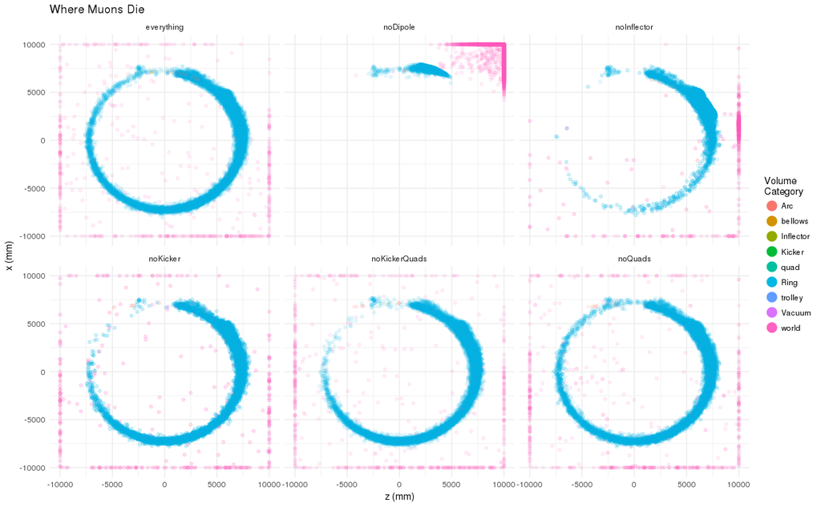

```r
trackingActionNVDF %>% filter(trackID == 1) %>%
  ggplot( aes(x=z, y=x, color=volCategory)) +
    geom_point(alpha=0.1) +
    ggtitle('Where Muons Die') +
    facet_wrap(~scenario) +
    guides(col = guide_legend(override.aes = list(size=5, alpha=1))) +
    scale_color_discrete(name="Volume\nCategory") +
    labs(x="z (mm)", y="x (mm)") +
    theme_minimal()
```

Here it is without the ring losses, which dominate

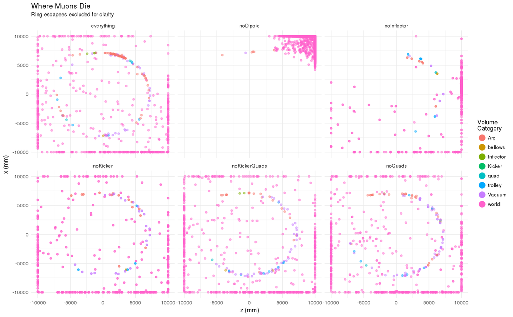

```r
trackingActionNVDF %>% filter(trackID == 1, volCategory != 'Ring') %>%
  ggplot( aes(x=z, y=x, color=volCategory)) +
    geom_point(alpha=0.5) +
    facet_wrap(~scenario) +
    guides(col = guide_legend(override.aes = list(size=5, alpha=1))) +
    ggtitle("Where Muons Die", subtitle = "Ring escapees excluded for clarity") +
    scale_color_discrete(name="Volume\nCategory") +
    labs(x="z (mm)", y="x (mm)") +
    theme_minimal()
```